# Resting State PreProcessing using GazeR

## install Gazer

I had some trouble getting this to go and had to mannually install some of the needed packages (ggforce).

library(devtools) install_github(“dmirman/gazer”) library(ggforce)

## 15 second subset of data for demonstration purposes

Read in and plot the data

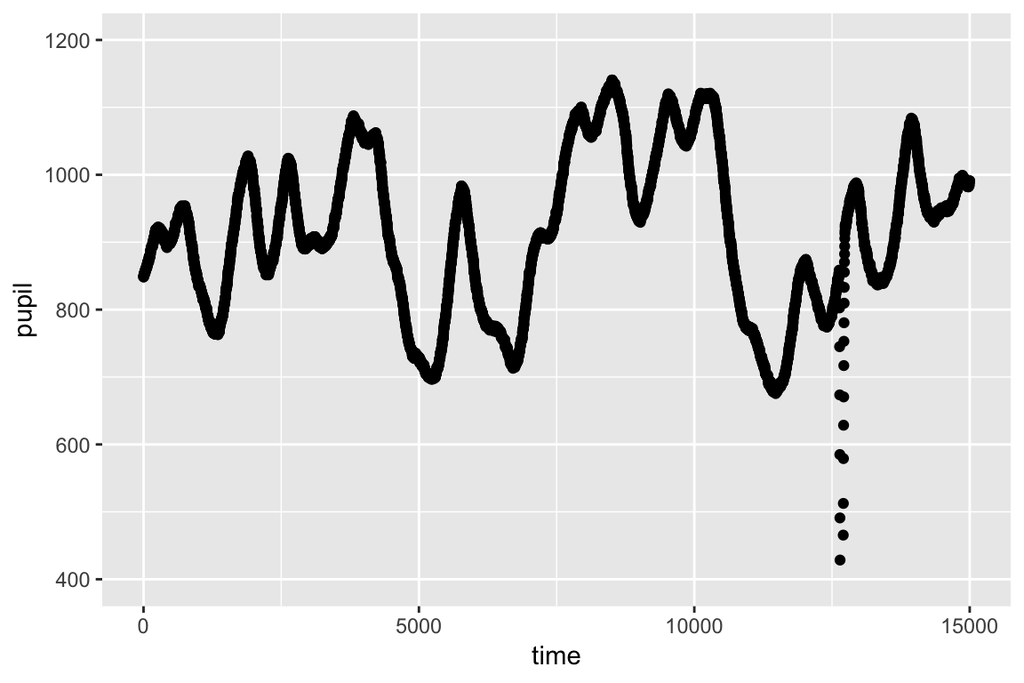

```r
library(tidyverse)
library(gazer)

bz4min <-read.csv("bz4gazer.csv", header =T)


pup_files1 <-arrange(bz4min, subject, trial, time) %>%
  filter(time>= 0, time <= 15000)

ggplot(data=pup_files1, aes(x=time, y=pupil)) + geom_point() + ylim(400, 1200)
```

```r
pup_missing <- count_missing_pupil(pup_files1, missingthresh = .2)
```

```
## % trials excluded:0
```

```
## Participants taken out:
```

## De-blink

remove blinks AND 100ms window on each side of blink

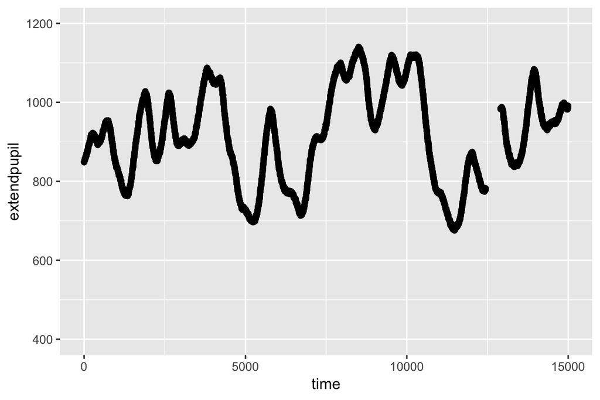

```r
pup_extend<- pup_missing %>%
  group_by(subject, trial) %>%
  mutate(extendpupil=extend_blinks(pupil, fillback=100, fillforward=100, hz=1000))

ggplot(data=pup_extend, aes(x=time, y=extendpupil)) + geom_point() + ylim(400, 1200)
```

## Removing other bad data

Unsure where this should go. Would be more informative after convertion to mm. If there are outliers there we will have to remove them and go through the process again starting at interpolation.

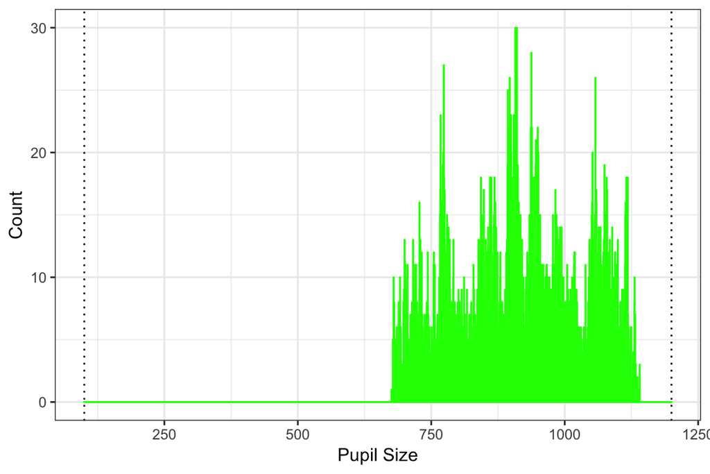

```r
puphist <- ggplot(pup_extend, aes(x = extendpupil)) +
  geom_histogram(aes(y = ..count..), colour = "green", binwidth = 0.5)  +
  geom_vline(xintercept = 100, linetype="dotted") +
  geom_vline(xintercept = 1200, linetype="dotted") +
  xlab("Pupil Size") +
  ylab("Count") +
  theme_bw()

print(puphist)
```

### High band set low (1100) for demo purpose

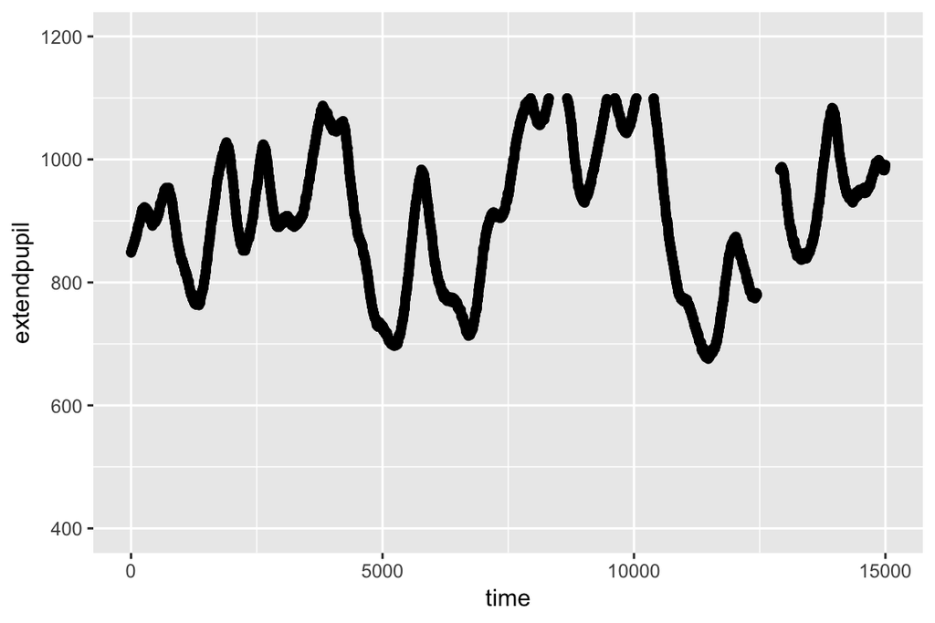

```r
pup_outliers <- pup_extend %>%
  mutate(extendpupil = replace(extendpupil, extendpupil<= 0 | extendpupil >= 1100, NA))

ggplot(data=pup_outliers, aes(x=time, y=extendpupil)) + geom_point() + ylim(400, 1200)
```

## Interpolate

performs a linear interpolation of missing values

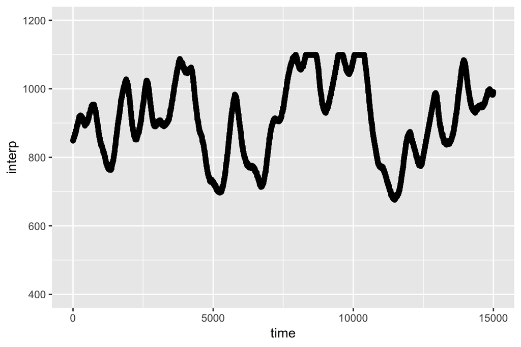

```r
pup_interp <- interpolate_pupil(
  pup_outliers,
  extendblinks = TRUE,
  type = "linear")

ggplot(data=pup_interp, aes(x=time, y=interp)) + geom_point() + ylim(400, 1200)
```

## MAD (speed of dialation)

May need to perform interpolation again after this step. MAD can not be performed with NAs in the dataset; at this time it must occur after interpolation.

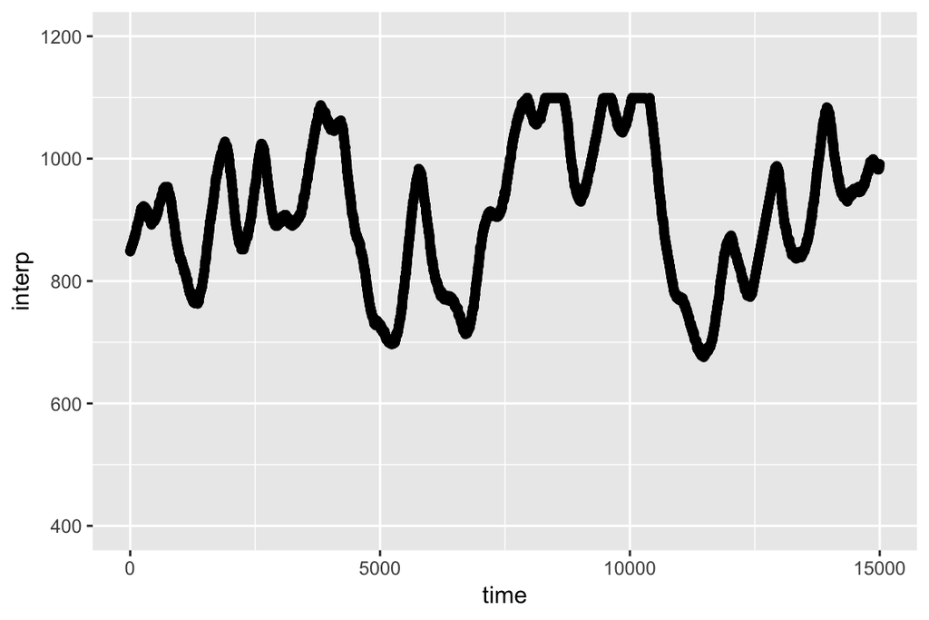

```r
mad_removal <- pup_interp %>%
  group_by(subject, trial) %>%
  mutate(speed=speed_pupil(interp,time)) %>%
  mutate(MAD=calc_mad(speed)) %>%
  filter(speed < MAD)

ggplot(data=mad_removal, aes(x=time, y=interp)) + geom_point() + ylim(400, 1200)
```

## Smoothing

### (currectly set to 20 for demo purposes)

uses a moving average to smooth

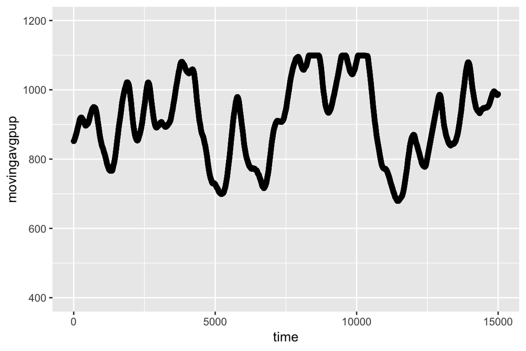

```r
rolling_mean_pupil_average <- as.data.frame(mad_removal) %>% #must be in a data.frame
  select(
    subject, trial, pupil,
    time, interp, sample_message) %>%
  mutate(movingavgpup = moving_average_pupil(interp, n = 20))

ggplot(data=rolling_mean_pupil_average, aes(x=time, y=movingavgpup)) + geom_point() + ylim(400, 1200)
```

## Baseline correction

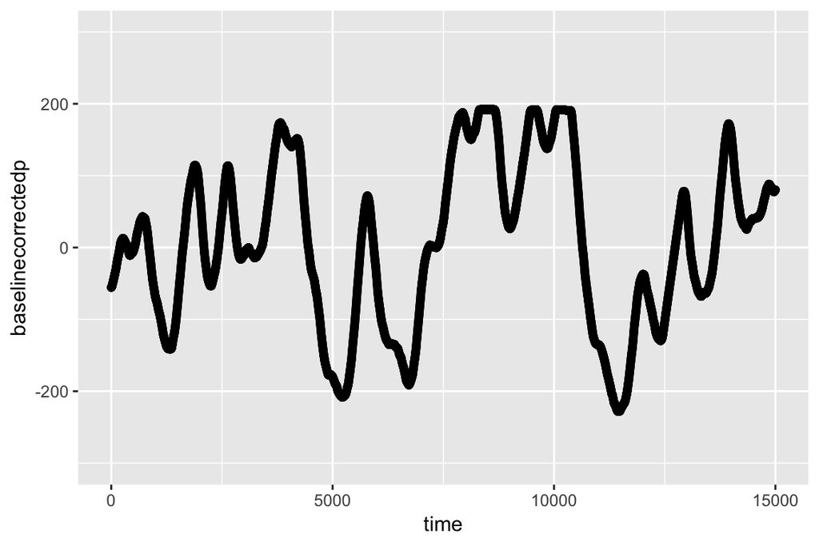

```r
baseline_pupil <- baseline_correction_pupil(
  rolling_mean_pupil_average,
  pupil_colnames = "movingavgpup",
  baseline_window = c(0, 1000))

ggplot(data=baseline_pupil, aes(x=time, y=baselinecorrectedp)) + geom_point() + ylim(-300, 300)
```

## Convert to meaningful units

### (we need to change this formula to fit our setup!!)

uses formula to change from abitrary unit to mm (we need to change this formula to fit our setup!!)

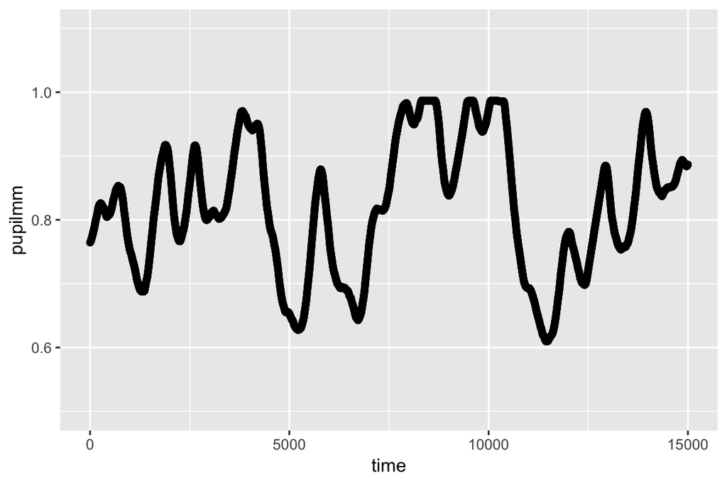

```r
timebinsmm <- rolling_mean_pupil_average  %>%
  mutate(pupilmm = (movingavgpup * 5)/5570.29)

ggplot(data=timebinsmm, aes(x=time, y=pupilmm)) + geom_point() + ylim(.5, 1.1)
```

## Change trial onset to Zero

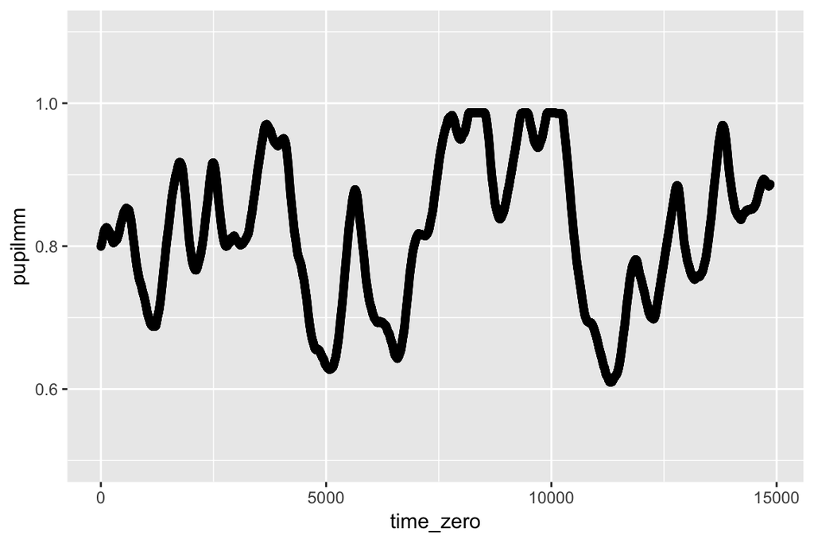

```r
baseline_pupil_onset <- timebinsmm %>%
  group_by(subject, trial) %>%
  mutate(time_zero= onset_pupil(time, sample_message, event = c("Simple_Start") )) %>%
  ungroup() %>%
  filter(time_zero >= 0, time_zero <= 15000) %>%
  select(
    subject, trial, time, time_zero,
    sample_message, pupilmm)

ggplot(data=baseline_pupil_onset, aes(x=time_zero, y=pupilmm)) + geom_point() + ylim(.5, 1.1)
```

## Binning

adds column assinging bin

```r
timebins1 <- downsample_pupil(baseline_pupil_onset, bin.length=200)

head(timebins1)
```

```
## # A tibble: 6 x 7
##   subject trial  time time_zero sample_message pupilmm timebins
##   <fct>   <int> <int>     <int> <fct>            <dbl>    <dbl>
## 1 BZ4min      1   142         0 Simple_Start     0.800        0
## 2 BZ4min      1   144         2 <NA>             0.800        0
## 3 BZ4min      1   146         4 <NA>             0.801        0
## 4 BZ4min      1   148         6 <NA>             0.801        0
## 5 BZ4min      1   150         8 <NA>             0.802        0
## 6 BZ4min      1   152        10 <NA>             0.802        0
```

groups and summarizes on bins

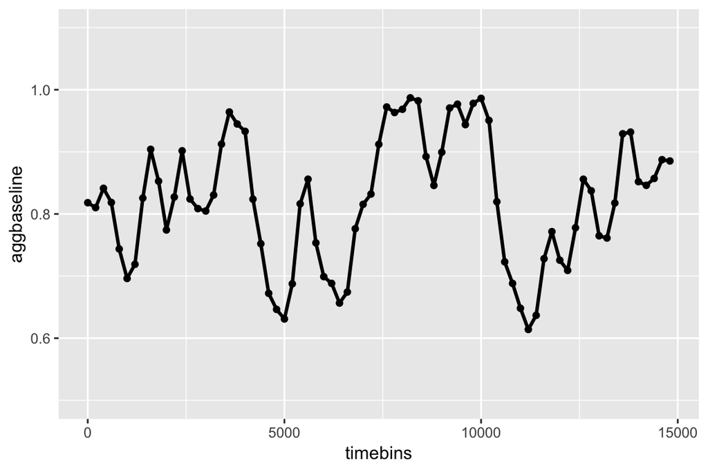

```r
agg_subject<- timebins1 %>%
  dplyr::group_by(subject,timebins) %>%
  dplyr::summarise(aggbaseline=mean(pupilmm)) %>%
  ungroup()

ggplot(data=agg_subject, aes(x=timebins, y=aggbaseline)) + geom_point() + geom_line(size = 1) + ylim(.5, 1.1)
```